# APSTA-GE: 2003 Intermediate Quantitative Methods

Group Exercise Sample Solution

14 October 2020

## Description

This file is for the group assignment of **APSTA-GE: 2003 Intermediate Quantitative Methods** course in Fall 2020.

It contains sample solutions using base R.

All code chunks are heavily scaffolded with detail explanations to show the logic behind solutions.

### Data processing

Load `lung_capacity0.csv`, and add a new column labelling the row ID.

**Answer:**

```r
# Load data
# Add a new column: ID: row number
dat <- read.csv("lung_capacity0.csv")
# Create a new column called "ID" and assign the number of rows.
dat$ID <- 1:nrow(dat) # assign 1 to 80 to the "ID" column in `dat`
```

### Question 1

How does lung capacity change as people get older? (in one sentence)

**Answer:**

```r
# Compute the correlation between lung capacity and age
cor(dat$LungCapacitycc, dat$Age)
```

```
## [1] 0.1278555
```

Originally, we thought that lung capacity decreases as people getting older, on average. However, the correlation between lung capacity and age is approximately 0.13. The correlation is not strong enough to observe a clear pattern of association. Therefore, age may not have strong influences on lung capacity.

#### 1a

Make a scatter plot of lung capacity (on y-axis) and age (on x-axis).

Eyeball the pattern. What do you see? (in one or two sentences)

**Answer:**

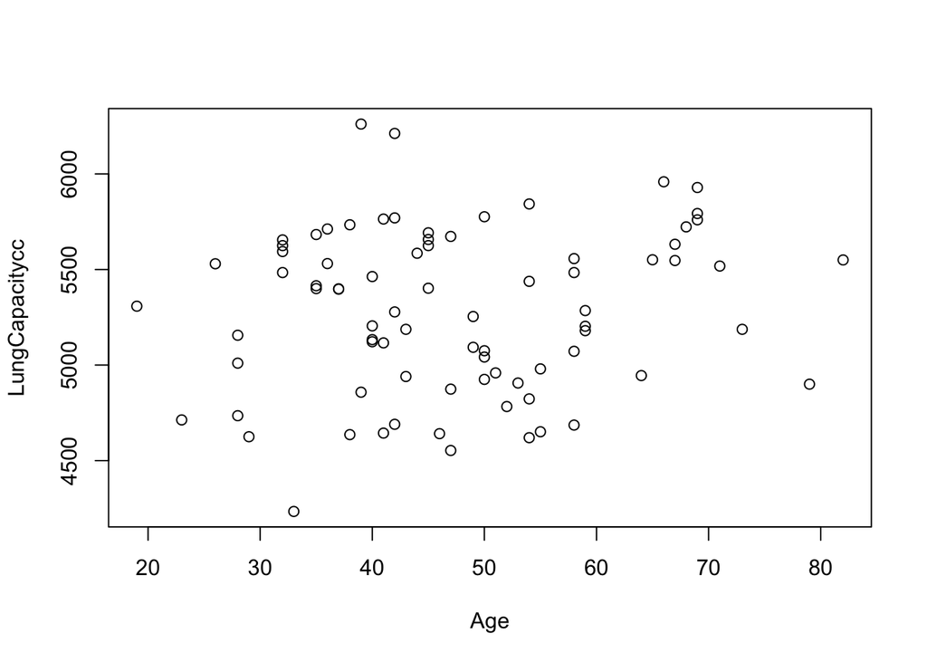

```r
# Create a scatter plot: LungCapacitycc (on y-axis) ~ Age (on x-axis)
plot(LungCapacitycc ~ Age, data = dat)
```

The distribution of lung capacity over age is diverse. We did not observe a clear pattern here.

#### 1b

Report the sample size.

**Answer:**

```r
nrow(dat)
```

```
## [1] 80
```

### Question 2

Conduct a regression analysis to answer the following questions: - Which variable is the dependent variable (D.V.)? - Which variable is the independent variable (I.V.)?

**Answer:**

```r
# Fit a regression model: LungCapacitycc ~ Age
lm_Q2 <- lm(LungCapacitycc ~ Age, data = dat)
summary(lm_Q2)
```

```
##
## Call:
## lm(formula = LungCapacitycc ~ Age, data = dat)
##
## Residuals:
##     Min      1Q  Median      3Q     Max
## -989.92 -344.80   73.47  354.20 1012.95
##
## Coefficients:
##             Estimate Std. Error t value Pr(>|t|)
## (Intercept) 5091.225    174.047  29.252   <2e-16 ***
## Age            4.021      3.532   1.139    0.258
## ---
## Signif. codes:  0 '***' 0.001 '**' 0.01 '*' 0.05 '.' 0.1 ' ' 1
##
## Residual standard error: 424.5 on 78 degrees of freedom
## Multiple R-squared:  0.01635,    Adjusted R-squared:  0.003736
## F-statistic: 1.296 on 1 and 78 DF,  p-value: 0.2584
```

The dependent variable is `lung capacity`. The independent variable is `age`.

### Question 3

Answer below questions based on the regression result.

#### 3a

What’s the regression coefficient of `age` on `lung capacity`?

Report the appropriate regression coefficient and its standard error (S.E.).

**Answer:**

```r
# Get the coefficient part of model summary
summary(lm_Q2)$coefficients
```

```
##                Estimate Std. Error   t value     Pr(>|t|)
## (Intercept) 5091.225327  174.04740 29.251947 8.452425e-44
## Age            4.021085    3.53181  1.138534 2.583826e-01
```

The intercept is 5091.225. The standard error is 174.047.

The slope is 4.021. The standard error is 3.532.

The regression equation, in this case, is:

$$\text{Lung Capacity} = 5091.225 + 4.021 \times \text{Age}$$

#### 3b

Is this coefficient statistically significant? What test did you use?

Write down the null and alternative hypotheses.

Report test statistic and p-value.

**Answer:**

We used hypothesis test.

**Null**: There is no relationship between people’s lung capacity and age.

**Alternative:** There exists a relationship between people’s lung capacity and age.

```r
# Report the second row of model coefficients
summary(lm_Q2)$coefficients[2, ]
```

```
##   Estimate Std. Error    t value   Pr(>|t|)
##  4.0210846  3.5318103  1.1385336  0.2583826
```

This coefficient is not statistically significant because the p-value is greater than 0.05.

#### 3c

Report a 95% confidence interval for the regression coefficient of age on lung capacity based on the results from the model.

**Answer:**

```r
confint(lm_Q2)
```

```
##                  2.5 %     97.5 %
## (Intercept) 4744.72357 5437.72708
## Age           -3.01021   11.05238
```

The 95% confidence interval for the coefficient of `age` on `lung capacity` is between -3.01 and 11.052.

### Question 4

Based on the model, calculate the fitted values and residuals for all observations in the model. Answer the following questions based on your results.

#### 4a

What are the mean values of the fitted values and residuals?

**Answer:**

```r
# Calculate the mean value of fitted values
mean(predict(lm_Q2))
```

```
## [1] 5281.875
```

```r
# Calculate the mean value of residuals
mean(residuals(lm_Q2))
```

```
## [1] 2.456577e-14
```

#### 4b

Calculate or report the total sum of squares (TSS), model sum of squares (MSS) and residual sum of squares (RSS).

**Verify that: TSS = MSS + RSS**

**Answer:**

Option 1: manual calculation

$$\begin{align}
TSS & = \sum_{i=1}^n (Y_i - \overline{Y})^2 \\
MSS & = \sum_{i=1}^n (\hat{Y_i} - \overline{Y})^2 \\
RSS & = \sum_{i=1}^n (Y_i - \hat{Y_i})^2 \\
\end{align}$$

```r
# Calculate total sum of squares
TSS <- sum((dat$LungCapacitycc - mean(dat$LungCapacitycc))^2)
# Calculate model sum of squares
MSS <- sum((predict(lm_Q2) - mean(dat$LungCapacitycc))^2)
# Calculate residual sum of squares
RSS <- sum((dat$LungCapacitycc - predict(lm_Q2))^2)

# Check if TSS = MSS + RSS
round(TSS) == round(MSS) + round(RSS)
```

```
## [1] TRUE
```

Option 2: use the `anova` function

```r
#use var function to calculate TSS
TSS <- var(dat$LungCapacitycc)*(nrow(dat)-1)
anova(lm_Q2)
```

|  | Df | Sum Sq | Mean Sq | F value | Pr(>F) |
| --- | --- | --- | --- | --- | --- |
| Age | 1 | 233569.2 | 233569.2 | 1.296259 | 0.2583826 |
| Residuals | 78 | 14054601.5 | 180187.2 | NA | NA |

Model sum of squares (MSS) = 233,569

Residual sum of squares (RSS) = 14,054,602

Total sum of squares (TSS) = 14,288,171

TSS = RSS + MSS

#### 4c

What’s the R-square of this model?

**Answer:**

```r
summary(lm_Q2)$r.squared
```

```
## [1] 0.01634703
```

#### 4d

What’s the correlation between lung capacity and age?

**Verify that the R-square is the correlation squared.**

**Answer:**

```r
# Report the correlation between lung capacity and age
cor(dat$LungCapacitycc, dat$Age)
```

```
## [1] 0.1278555
```

```r
# Calculate squared correlation
cor(dat$LungCapacitycc, dat$Age)^2
```

```
## [1] 0.01634703
```

```r
# Report R-squared
summary(lm_Q2)$r.squared
```

```
## [1] 0.01634703
```

```r
# Examine if the squared correlation is equal to r-squared
round(cor(dat$LungCapacitycc, dat$Age)^2) == round(summary(lm_Q2)$r.squared)
```

```
## [1] TRUE
```

### Question 5

Based on this model, how much difference do we expect to see between 20 years old and 25 year old? And between 60 years old and 65 years old?

**Hint:** By the nature of linear relationships, it doesn’t matter at what age ranges. This Model assumes that 1 year age difference leads to the same change in lung capacity.

**Answer:**

To solve this, we can directly use the property of a line.

The **slope** means that when the independent variable, `X`, increases 1 unit, the dependent variable, `Y`, will increase $\beta_1$ unit. It doesn’t matter whether `X` changes from 20 to 21, or 50 to 51.

This also means that a 5-unit increase in `X`, say from 20 to 25, or from 50 to 55, leads to $5 \times \beta_1$ unit change in `Y`.

The average change in `lung capacity` associated with a 5-year increase in `age` is:

```r
5 * coefficients(lm_Q2)["Age"]
```

```
##      Age
## 20.10542
```

Alternatively, we can calculate the fitted values at different Ages then compared the differences.

```r
# Create new dataset and store independent variables for prediction
new_dat <- data.frame(Age = c(20, 25, 60, 65))
# Predict lung capacity using the new dataset
predict(lm_Q2, newdata = new_dat)
```

```
##        1        2        3        4
## 5171.647 5191.752 5332.490 5352.596
```

```r
# Difference between 20 and 25 years old
predict(lm_Q2, newdata = new_dat)[2] - predict(lm_Q2, newdata = new_dat)[1]
```

```
##        2
## 20.10542
```

```r
# Difference between 60 and 65 years old
predict(lm_Q2, newdata = new_dat)[4] - predict(lm_Q2, newdata = new_dat)[3]
```

```
##        4
## 20.10542
```

Another interesting question:

Can you prescribe a 95% confidence interval for the average difference in `lung capacity` associated with a 5-year age difference?

**Hint:** $\beta_1$ is the difference due to 1-year difference in age. $5 * \beta_1$ is the difference due to a 5-years difference in age.

**Answer:**

```r
# Calculate: slope * 5
# Select the slope from the model summary
summary(lm_Q2)$coefficients[2, "Estimate"] * 5
```

```
## [1] 20.10542
```

Now the standard error in $\hat{\beta_1}$ is ___?

**Answer:**

```r
# Get the standard error for the slope from the model summary
# Note: this is a different way to pull out the slope coefficient from
# regression results
summary(lm_Q2)$coefficients[2, "Std. Error"]
```

```
## [1] 3.53181
```

What’s the standard error in $5 \times \hat\beta_1$?

**Answer:**

It is $5 \times S.E.$ of the slope coefficient estimate.

$$\begin{align}
SE(5 \times \hat\beta_1) & = \sqrt{Var(5 \times \hat\beta_1)} \\
& = \sqrt{25 \times Var(\hat\beta_1}) \\
& = 5 \sqrt{Var(\hat\beta_1)} \\
& = 5 \times SE(\hat\beta_1)
\end{align}$$

```r
# Get the standard error for 5 * slope
summary(lm_Q2)$coefficients[2, "Std. Error"] * 5
```

```
## [1] 17.65905
```

```r
# Calculate the confidence interval for 5 * slope
slope_Q5 <- summary(lm_Q2)$coefficients[2, "Estimate"] * 5
se_Q5 <- summary(lm_Q2)$coefficients[2, "Std. Error"] * 5
slope_Q5 - 2 * se_Q5
```

```
## [1] -15.21268
```

```r
slope_Q5 + 2 * se_Q5
```

```
## [1] 55.42353
```

```r
# Validate with: 5 * CI(beta_1)
5 * confint(lm_Q2)["Age", ]
```

```
##     2.5 %    97.5 %
## -15.05105  55.26189
```

### Question 6

Estimate standardized regression coefficients using two different approaches.

#### 6a

Generate a new variable based on lung capacity by dividing its original value by its standard deviation.

**Answer:**

```r
# Calculate standardized lung capacity and store the result as a new column
# in the original dataset
dat$std_lungCap <- dat$LungCapacitycc / sd(dat$LungCapacitycc)
```

Generate a new variable based on age by dividing its original value by its standard deviation. Run a regression using these two new variables. Report the regression coefficients (intercept and slope)

**Answer:**

```r
# Calculate standardized age and store the result in `dat`
dat$std_age <- dat$Age / sd(dat$Age)

# Fit a new regression model
lm_Q6 <- lm(std_lungCap ~ std_age, data = dat)
# Report coefficients
lm_Q6$coefficients
```

```
## (Intercept)     std_age
##  11.9714718   0.1278555
```

#### 6b

Use lm.beta to estimate the standardized regression coefficients.

**Answer:**

```r
lm.beta(lm_Q6)
```

```
##
## Call:
## lm(formula = std_lungCap ~ std_age, data = dat)
##
## Standardized Coefficients::
## (Intercept)     std_age
##   0.0000000   0.1278555
```

#### 6c

Compare standardized slope with correlation.

**Answer:**

```r
# Report standardized slope
lm_Q6$coefficients["std_age"]
```

```
##   std_age
## 0.1278555
```

```r
# Report correlation between lung capacity and age
cor(dat$LungCapacitycc, dat$Age)
```

```
## [1] 0.1278555
```

Standardized slope is equal to correlation.

#### 6d

What is the meaning of the intercept now?

By standardization, we are able to compare the relationship between two variables which originally have different measurement units. In this case, lung capacity is measured in `cc` while age is measured in `year`.

### Question 7

Regression Diagnostics

**Hint:** There are (at least) two R packages you can use, the `stat` package (more traditional, `?influence.measures`) and the `car` package that provides more stylized plots.

#### 7a

What’s the difference between standardized residuals and studentized residuals?

**Answer:**

The relationship between **standardized** residual and **studentized** residual is:

$$\begin{align}
r_i & = Y_i - \hat{Y}_i \\
s_i & = \frac{r_i}{\hat{\sigma}} \\
t_i & = \frac{r_i}{\hat{\sigma}_{(-i)}}
\end{align}$$

where $r_i$ is the $i^{th}$ residual, $\hat{\sigma}$ is the standard deviation of the residuals, and $\hat{\sigma}_{-i}$ is the standard deviation of the residuals calculated without the $i^{th}$ point. $s_i$ is the standardized residual and $t_i$ is the studentized residual.

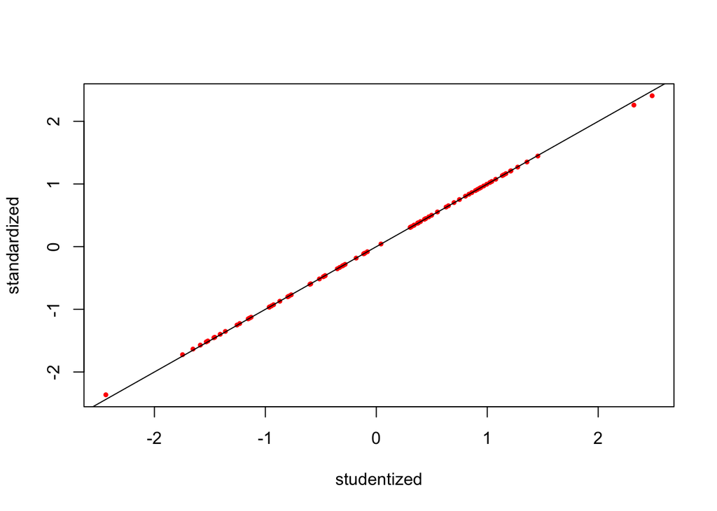

```r
# Calculate standardized residuals and store the result as `stand_res`
## Option 1:
stand_res <- residuals(lm_Q2) / sd(residuals(lm_Q2))
## Option 2:
stand_res <- rstandard(lm_Q2)

# Calculate studentized residuals
## Option 1: using the built-in R function
stu_residual <- rstudent(lm_Q2)
## Option 2: using for loop
# Create an empty vector to store results
stu_residual2 <- rep(NA, each = nrow(dat))
# FOR i iterating from 1 to the number of rows (n = 80):
for (i in 1:nrow(dat)) {
  stu_residual2[i] <- residuals(lm_Q2)[i] / sd(residuals(lm_Q2)[-i])
}

# Note:
# 1. There are other versions of functions that can calculate studentized
# residuals.
# 2. The essence is to leave one out in the calculation.

# Visualize the differentce between studentized residuals and standardized
# residuals
plot(x = stu_residual, y = stand_res,
     pch = 19,                 # Point Character Style: 19
     xlab = "studentized",     # Label for the x-axis
     ylab = "standardized",    # Label for the y-axis
     cex = 0.5,                # Zoom out to 50%
     col = "red")              # Set color as red
abline(a = 0, b = 1)           # Draw a reference line
```

```r
                               # Intercept = 0
                               # Slop = 1
```

Examine two figures: residuals versus $\hat{Y}$ and residuals versus Age.

**Answer:**

These two figures are almost identical, except the x axis for one is $\hat{Y}$ and `Age` for the other one. (In multiple regression, these two figures will be different, as other variables will affect $\hat{Y}$ as well.)

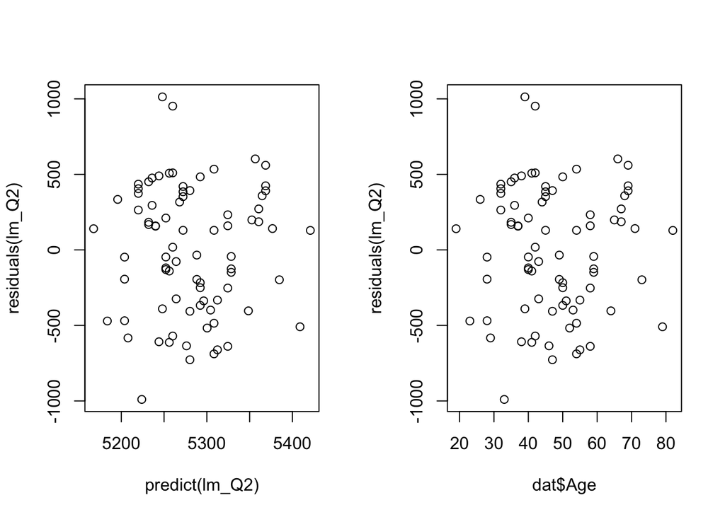

```r
# Create a 1-by-2 grid
par(mfrow = c(1, 2))
# Plot residuals against fitted lung capacity
plot(x = predict(lm_Q2), y = residuals(lm_Q2))
# Plot residuals against age
plot(x = dat$Age, y = residuals(lm_Q2))
```

Any outliers? Use -2 and 2 as fences.

**Answer:**

```r
# Detect outliers using studentized residuals.
# Store the index of studentized residuals that is greater than 2 or smaller
# than -2.
index <- which(stu_residual > 2 | stu_residual < -2)
# Subset outliers from the original dataset using index
dat_outlier <- dat[index, ]
print(dat_outlier)
```

```
##    Sex Height Smoker Exercise Age LungCapacitycc ID std_lungCap  std_age
## 6    1   76.1      0       39  42           6212  6   14.606854 3.105977
## 14   0   58.9      1        1  33           4234 14    9.955798 2.440411
## 19   1   76.6      0       40  39           6261 19   14.722072 2.884122
```

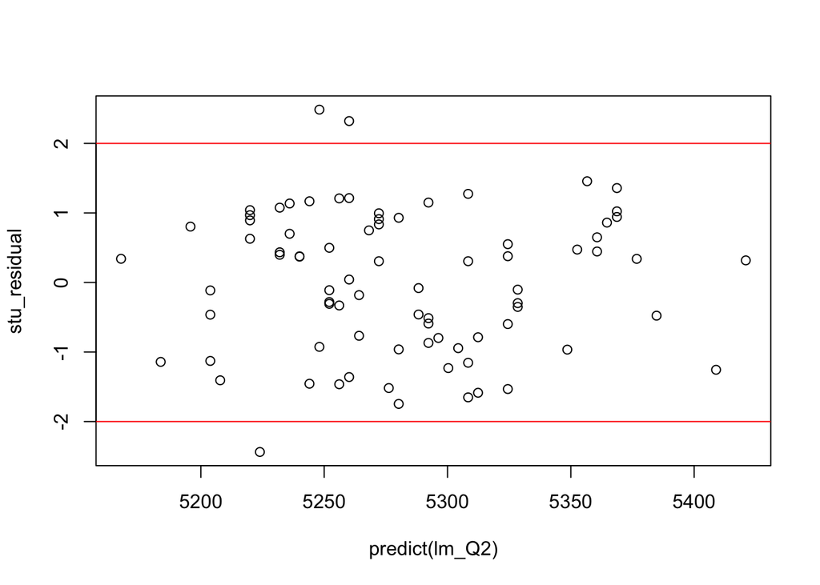

```r
# Visualize outliers, using -2 and 2 as fences
plot(x = predict(lm_Q2), y = stu_residual)
abline(h = -2, col = "red")     # Draw a horizontal line at y = -2
abline(h =  2, col = "red")
```

##### 7a iii

Based on eyeballing, does linear relationship hold?

**Answer:**

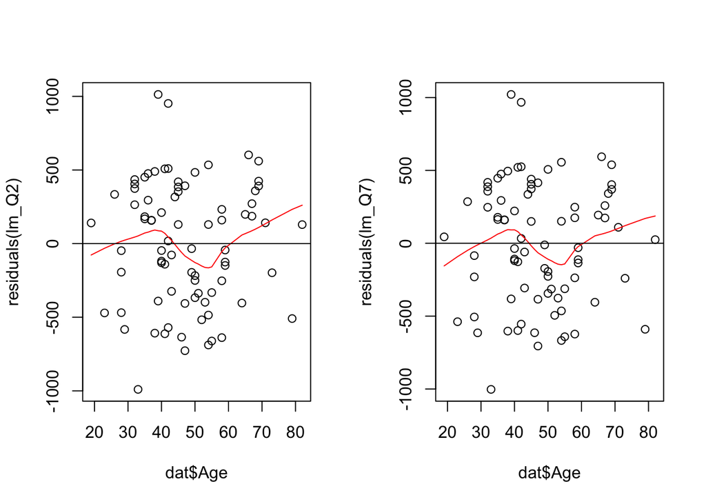

```r
# Create a 1-by-2 grid
par(mfrow = c(1, 2))
# Plot Residuals vs. predictor (Age) using linear model: lm_Q2
plot(dat$Age, residuals(lm_Q2))
lines(lowess(residuals(lm_Q2) ~ dat$Age), col = "red") # Add a smooth trend line
abline(h = 0)

# Fit a new regression model with a new quadratic term
dat$Age2 <- dat$Age^2
lm_Q7 <- lm(LungCapacitycc ~ Age + Age2, data = dat)
# Plot Residuals vs. predictor (Age) using model: lm_Q7
plot(dat$Age, residuals(lm_Q7))
lines(lowess(residuals(lm_Q7) ~ dat$Age), col = "red")
abline(h = 0)
```

The red line is smoothed trend line. In general, when the linear relationship holds, we shouldn’t expect to see any trend between residuals and the predictor. The left panel plots residuals versus `Age`, and the red line is the trend line. It doesn’t seem like there is much of trend going up or down, or a particular quadratic shape (*we will get back to this point when we talk about polynomial regression.*) The right panel shows the residuals versus `Age` plot based on the model that the squared `Age` term is included. In this partiular example, we don’t see much change.

##### Question 7a iv

Based on eyeballing, does equal variance hold?

**Answer:**

The spread of residuals (along vertical axis) appears to be reasonably equal along the x-axis. **This suggests that equal variance is a reasonable assumption.**

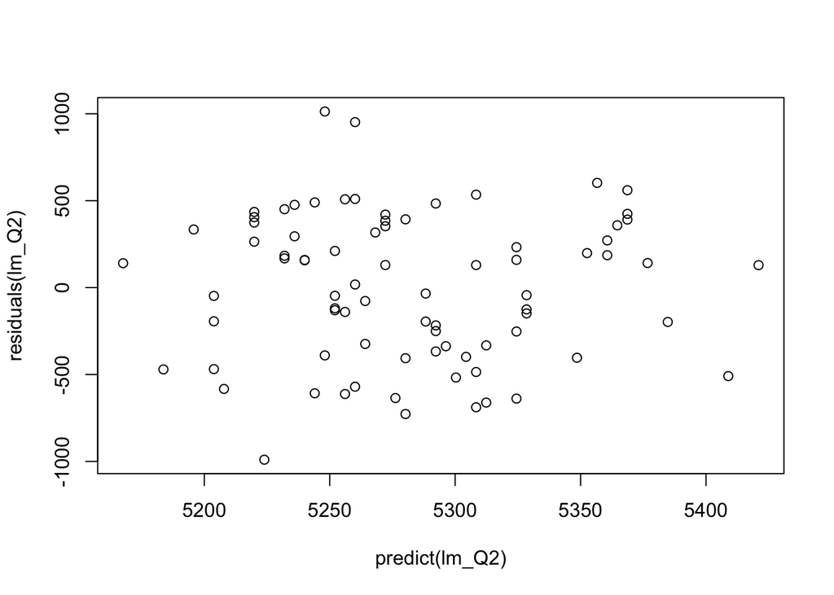

```r
plot(x = predict(lm_Q2), y = residuals(lm_Q2))
```

Examine whether the normality assumption holds.

**Answer:**

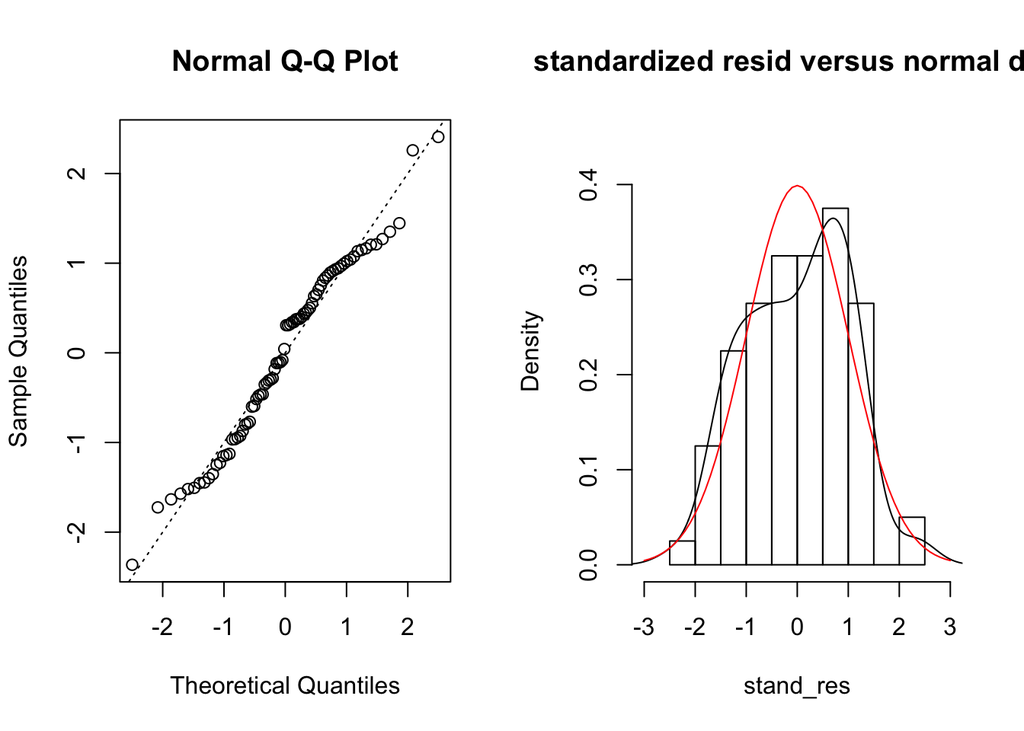

```r
# Create a 1-by-2 grid
par(mfrow = c(1, 2))
# Check normality using qq-plot
qqnorm(stand_res)
# Draw a 45-degree abstract reference line with intercept = 0, slope = 1
abline(a = 0, b = 1, lty = "dotted")
# Plot a histogram to examine the distribution of standardized residuals
hist(stand_res,
     freq = FALSE,        # FALSE for probability density
     xlim = c(-3,3),      # x axis limits
     ylim = c(0,0.45),    # y axis limits
     main = "standardized resid versus normal dist")
lines(density(stand_res)) # Add a density reference line in black
# Add a normal reference line in red
lines(x = seq(from = -3, to = 3, by = 0.1),
      y = dnorm(seq(from = -3, to = 3, by = 0.1), mean = 0, sd = 1),
      col = "red")
```

**Left panel**: Q-Q plot of the residual terms allow us to examine the normality assumption.

**Right panel**: histogram of the standardized residuals is compared with the normal distribution.

In this case, the normality assumption doesn’t hold very nicely, but, on the other hand, there is no obvious deviation (i.e. the distribution is still largely symmetric and unimodal).

Any observations have leverage, and high influence?

Eyeball by overlaying the fitted line - outliers along x and y axes?

**Answer:**

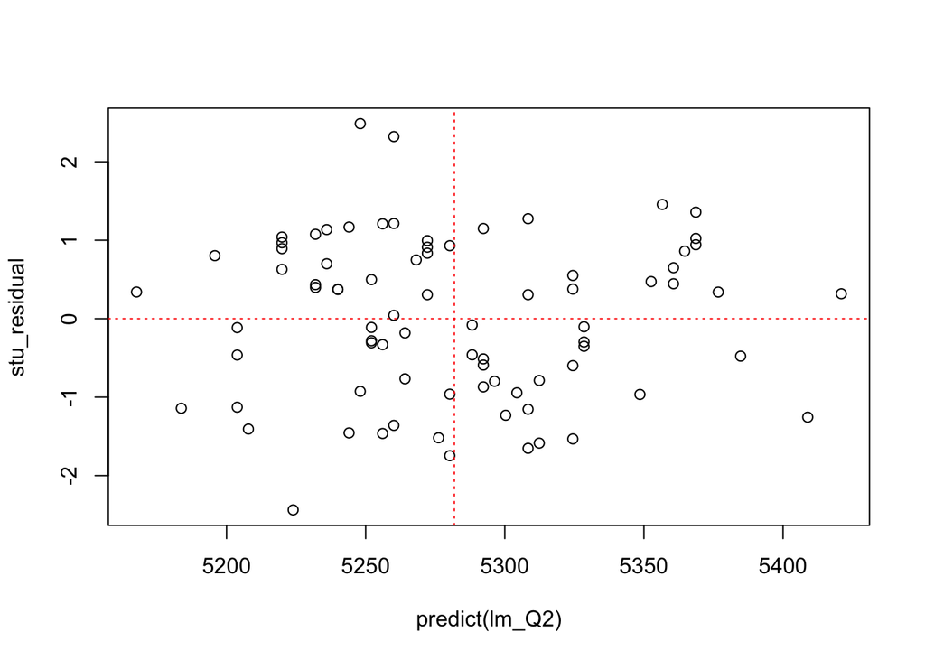

```r
# Reprint the plot
plot(x = predict(lm_Q2), y = stu_residual)
# Draw two fitted lines for reference
abline(h = mean(stu_residual), col = "red", lty = "dotted")
abline(v = mean(predict(lm_Q2)), col = "red", lty = "dotted")
```

Use a fancy plot.

**Answer:**

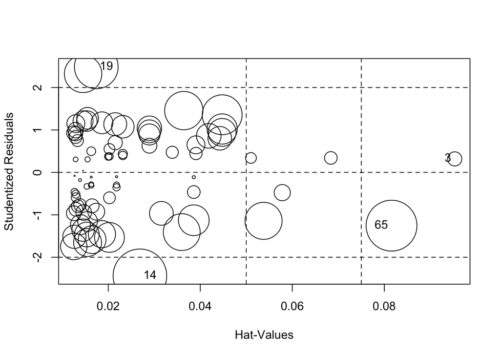

|  | StudRes | Hat | CookD |
| --- | --- | --- | --- |
| 3 | 0.317772 | 0.09531503 | 0.005381459 |
| 14 | -2.437797 | 0.02687969 | 0.077185973 |
| 19 | 2.486000 | 0.01739915 | 0.051309520 |
| 65 | -1.255565 | 0.08157189 | 0.069493757 |

```r
# Plot a fancy influence plot
# Circle size is proportial to Cook's Distance
influencePlot(lm_Q2)
```

**Observations 65, 14 and 19 appear to have the largest Cook’s Distance.**

Examine influence measures **Cook’s Distance** and **Dffits**.

**Answer:**

```r
# Option 1
summary(influence.measures(lm_Q2))
```

```
## Potentially influential observations of
##   lm(formula = LungCapacitycc ~ Age, data = dat) :
##
##    dfb.1_ dfb.Age dffit cov.r   cook.d hat
## 3  -0.08   0.10    0.10  1.13_*  0.01   0.10_*
## 6   0.17  -0.11    0.28  0.91_*  0.04   0.01
## 13  0.09  -0.08    0.09  1.10_*  0.00   0.07
## 14 -0.36   0.30   -0.41  0.91_*  0.08   0.03
## 19  0.25  -0.18    0.33  0.89_*  0.05   0.02
## 33  0.09  -0.10   -0.12  1.08_*  0.01   0.06
## 65  0.29  -0.34   -0.37  1.07    0.07   0.08_*
## 77 -0.06   0.07    0.08  1.08_*  0.00   0.05
```

```r
# Option 2: compute all measures
dat$cooksD <- cooks.distance(lm_Q2)                    # Cook's distance
dat$dffits <- dffits(lm_Q2)                            # Diffits
dat$leverage <- hatvalues(lm_Q2)                       # Find large hat values
# Detect influential points
influenceID <- dat$ID[dat$cooksD > 4/nrow(dat)]        # Threshold: 4/n
dffitsID <- dat$ID[dat$dffits>2 / (sqrt(2/nrow(dat)))] # Threshold: 2/sqrt(2/n)
dat$stand_res <- stand_res
# Detect outliers
outlierID <- dat$ID[abs(dat$stand_res) > 2]            # Greater than two-sigma
# Create a vector to store the index of influential points
star.points <- union(influenceID, dffitsID)
star.points <- union(star.points, outlierID)
print(dat[star.points, ])
```

```
##    Sex Height Smoker Exercise Age LungCapacitycc ID std_lungCap  std_age Age2
## 14   0   58.9      1        1  33           4234 14    9.955798 2.440411 1089
## 19   1   76.6      0       40  39           6261 19   14.722072 2.884122 1521
## 65   0   65.1      1       17  79           4900 65   11.521826 5.842195 6241
## 6    1   76.1      0       39  42           6212  6   14.606854 3.105977 1764
##        cooksD     dffits   leverage stand_res
## 14 0.07718597 -0.4051598 0.02687969 -2.364043
## 19 0.05130952  0.3308085 0.01739915  2.407346
## 65 0.06949376 -0.3741853 0.08157189 -1.250951
## 6  0.03761282  0.2818855 0.01452799  2.258927
```

##### 7a vi

Remove outlier data points, what happens? Things to check: - p-value of $\beta_1$, difference in values of new and old $\beta_1$ estimates. - SE values of new and old $\beta_1$ estimates. - R squares of the new and old models.

**Answer:**

```r
# Remove outliers from the original dataset using index
dat_no_outlier <- dat[-outlierID, ]
# Fit a new regression model
lm_Q7_no_out <- lm(LungCapacitycc ~ Age, data = dat_no_outlier)
# Get the model summary
summary(lm_Q7_no_out)
```

```
##
## Call:
## lm(formula = LungCapacitycc ~ Age, data = dat_no_outlier)
##
## Residuals:
##     Min      1Q  Median      3Q     Max
## -714.57 -324.59   30.45  346.52  615.35
##
## Coefficients:
##             Estimate Std. Error t value Pr(>|t|)
## (Intercept) 5079.363    160.959  31.557   <2e-16 ***
## Age            4.004      3.241   1.236    0.221
## ---
## Signif. codes:  0 '***' 0.001 '**' 0.01 '*' 0.05 '.' 0.1 ' ' 1
##
## Residual standard error: 385.2 on 75 degrees of freedom
## Multiple R-squared:  0.01995,    Adjusted R-squared:  0.006879
## F-statistic: 1.526 on 1 and 75 DF,  p-value: 0.2205
```

The p-value of $\beta_1$ does not change much. The old p-value is 0.258 while the new p-value is 0.221.

The old standard error is 3.532. The new statistic is 3.241. The standard error decreases, indicating that the model has better performance in estimation.

Remove influential data points, what happens?

**Answer:**

```r
# Update index to store influential points pulled from influentialPlot
# Remove influential points from the original dataset
dat_no_influ <- dat[-influenceID, ]
# Fit a new regression model
lm_Q7_no_influ <- lm(LungCapacitycc ~ Age, data = dat_no_influ)
# Get the model summary
summary(lm_Q7_no_influ)
```

```
##
## Call:
## lm(formula = LungCapacitycc ~ Age, data = dat_no_influ)
##
## Residuals:
##     Min      1Q  Median      3Q     Max
## -733.29 -344.77   95.37  344.71  949.76
##
## Coefficients:
##             Estimate Std. Error t value Pr(>|t|)
## (Intercept) 5060.236    169.471  29.859   <2e-16 ***
## Age            4.810      3.453   1.393    0.168
## ---
## Signif. codes:  0 '***' 0.001 '**' 0.01 '*' 0.05 '.' 0.1 ' ' 1
##
## Residual standard error: 396.3 on 75 degrees of freedom
## Multiple R-squared:  0.02521,    Adjusted R-squared:  0.01221
## F-statistic:  1.94 on 1 and 75 DF,  p-value: 0.1678
```

After excluding influential points, the model continues to perform better.

### 7b

Notice that, in the dataset, we didn’t really have high influential points nor high leverage points. For the curious minds, if we remove data points that have high leverage but not an outlier or influential, what will happen?

**Hint:** you can add a new observation with a pair of lung capacity and age values of your choice and attach this new row to the existing data.

**Sample Answer:**

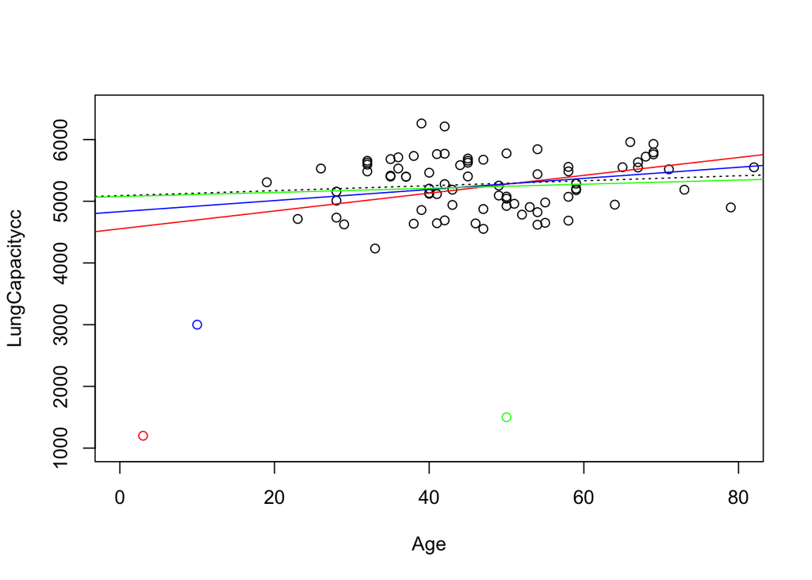

```r
# Replot the scatterplot with wider x and y axes ranges
plot(LungCapacitycc ~ Age, data = dat,
     xlim = c(0, 80),
     ylim = c(1000, 6500))
abline(a = coef(lm_Q2)[1], b = coef(lm_Q2)[2], lty = "dotted") # Original regression line
# Manually drop a few data points
points(10, 3000, col = "blue")     # An influential point?
points(3 , 1200, col = "red")      # Another influential point?
points(50, 1500, col = "green")    # Definitely an outlier, but influential?

# Duplicate the dataset
datnew <-dat
datnew <- rbind(datnew, rep(NA, ncol(datnew))) # Add a several new rows

# Red point
# Age: 3
# Lung capacity: 1200
datnew$Age[81] <- 3
datnew$LungCapacitycc[81] <- 1200
# Fit a new regression model
lm_Q_p1 <- lm(LungCapacitycc ~ Age, dat = datnew)
abline(a = coef(lm_Q_p1)[1], b = coef(lm_Q_p1)[2], col = "red") # Regression line

# Blue point
# Age: 10
# Lung capacity: 3000
datnew$Age[81] <- 10
datnew$LungCapacitycc[81] <- 3000
# Fit a new regression model
lm_Q_p2 <- lm(LungCapacitycc ~ Age, dat = datnew)
abline(a = coef(lm_Q_p2)[1], b = coef(lm_Q_p2)[2], col = "blue") # Reg line

# Green point
# Age: 50
# Lung capacity: 1500
datnew$Age[81] <- 50
datnew$LungCapacitycc[81] <- 1500
# Fit a new regression model
lm_Q_p3 <- lm(LungCapacitycc ~ Age, dat = datnew)
abline(a = coef(lm_Q_p3)[1], b = coef(lm_Q_p3)[2], col = "green") # Reg line
```

```r
# Measures for the red dot
cooks.distance(lm_Q_p1)[81]
```

```
##       81
## 2.857972
```

```r
hatvalues(lm_Q_p1)[81]
```

```
##        81
## 0.1297134
```

```r
rstandard(lm_Q_p1)[81]
```

```
##        81
## -6.192739
```

```r
# Measures for the blue dot
cooks.distance(lm_Q_p2)[81]
```

```
##        81
## 0.9749611
```

```r
hatvalues(lm_Q_p2)[81]
```

```
##         81
## 0.09860832
```

```r
rstandard(lm_Q_p2)[81]
```

```
##        81
## -4.221907
```

```r
# Measures for the green dot
cooks.distance(lm_Q_p3)[81]
```

```
##        81
## 0.2573223
```

```r
hatvalues(lm_Q_p3)[81]
```

```
##         81
## 0.01279758
```

```r
rstandard(lm_Q_p3)[81]
```

```
##        81
## -6.300759
```